# Investigating Tax Risk Management

## Summer School JGU Mainz — Advanced Methods in Behavioral Economics, 2021

### Carina I. Hausladen

```python
from datetime import datetime

print(datetime.now().strftime("%Y-%m-%d"))
```

```
2021-09-30
```

# Introduction

[Lavermicocca (2011)](https://heinonline.org/HOL/Page?handle=hein.journals/ejotaxrs9&div=9&g_sent=1&casa_token=4gQ_iUfuMUEAAAAA:95FZyqAl-ex8Cuk9HMwhLQNlgl1WEVpFDB6hZeLnurXsN1bA_zNg3MjkKBtdz5GK_QO2gD9niTs)

- How do tax risk management practices of large corporations in Germany look like?
- More precisely, we want to investigate
  - tax risk decision making
  - variables that impact tax risk
  - the ability to manage tax risk
  - tax risk management practices

# Data

```python
df = pd.read_csv('data/tax_risk_data_simulated.csv')
df.head()
```

|  | x | company | y1 | y2 | y3 |
| --- | --- | --- | --- | --- | --- |
| 0 | in the event of increases and decreases in val... | acs | 1 | 1 | 1 |
| 1 | ACS Group since 2011, has de? ned a risk con... | acs | 1 | 0 | 0 |
| 2 | rec oGnition Revenue is recognised to the... | acs | 0 | 0 | 0 |
| 3 | salary is paid into an external fund. In add... | acs | 0 | 0 | 0 |
| 4 | them. The lawsuits, although numerous, repre... | acs | 0 | 0 | 0 |

# Descriptive Statistics

## Information on labels (y)

- The labels are hand-coded.
- Three different labels exist:
  - tax risk rudimentary
  - tax risk extensive
  - tax risk management

```
The dataset has 23142 entries.
The plot shows that a very low percentage of paragraphs are labeled as referring to tax risk.
```

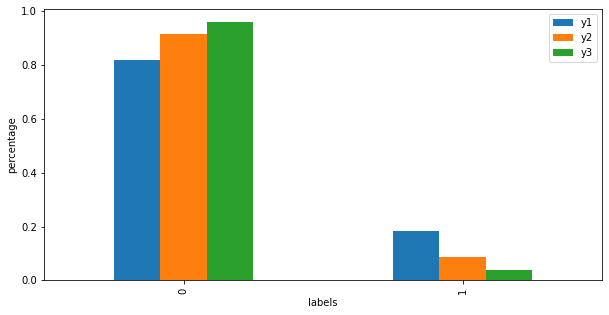

```python
y1_count = df.y1.value_counts(normalize=True)
y2_count = df.y2.value_counts(normalize=True)
y3_count = df.y3.value_counts(normalize=True)

df2 = pd.DataFrame()
df2['y1'] = y1_count
df2['y2'] = y2_count
df2['y3'] = y3_count

print('The dataset has', len(df), 'entries.')
df2.plot.bar(figsize=(10, 5))
plt.xlabel('labels')
plt.ylabel('percentage')
print('The plot shows that a very low percentage of paragraphs are labeled as referring to tax risk.')
```

## Information by company

The plot shows that most of the labels come from very few companies. Therefore key features learnt might be company-specific.

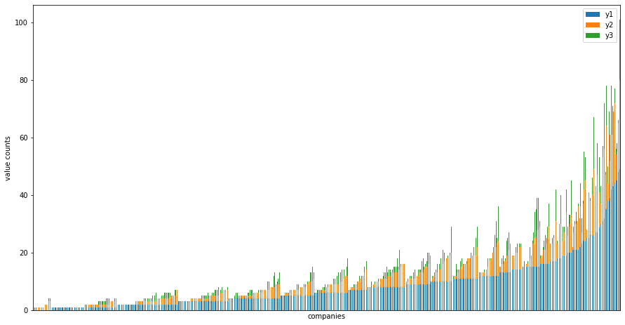

```python
df2.plot.bar(stacked=True, figsize=(15, 8))
plt.xticks([])
plt.xlabel('companies')
plt.ylabel('value counts')
```

## Annual Reports (X)

```python
print(len(df['x']))
```

```
23142
```

```python
#examine number of words per sample
df['x'].apply(lambda x: len(x.split(" "))).describe()
```

```
count    23142.000000
mean       122.467980
std         63.435621
min          9.000000
25%         81.000000
50%        109.000000
75%        147.000000
max        836.000000
Name: x, dtype: float64
```

### Basics

- Remove capitalization, punctuation, numbers, and stopwords.
- Unicode errors (produce by converting pdf to txt) are normalized via [NLTK](https://www.nltk.org).
- Stop words are going to be removed later (when vectorizing).

```python
def _remove_non_ascii(s):
    return "".join(i for i in s if ord(i) < 128)


def clean_text(text):
    text = text.lower()
    text = normalize('NFKD', text)
    text = re.sub(r'\W+', ' ', text)
    text = re.sub(r'\s+', ' ', text)
    text = re.sub(r"\\", "", text)
    text = re.sub(r"\'", "", text)
    text = re.sub(r"\"", "", text)
    text = re.sub('[^a-zA-Z ?!]+', '', text)
    text = _remove_non_ascii(text)
    text = text.strip()
    return text
```

### Stemming and Lemmatization

[nlp Stanford](https://nlp.stanford.edu/IR-book/html/htmledition/stemming-and-lemmatization-1.html)

- The goal of both stemming and lemmatization is to reduce inflectional forms.
- Sometimes derivationally related forms of a word should be transformed to a common base form.

am, are, is $\Rightarrow$ be  
car, cars, car's, cars' $\Rightarrow$ ca

- **Stemming** chops off the ends of words and often includes the removal of derivational affixes.
- **Lemmatization** uses vocabulary and morphological analysis of words.
  - It aims at removing inflectional endings only.
  - It returns the base or dictionary form of a word (lemma).

We deploy nltk's [WordNetLemmatizer()](http://www.nltk.org/_modules/nltk/stem/wordnet.html#WordNetLemmatizer) using WordNet's built-in [morphy function](https://wordnet.princeton.edu/documentation/morphy7wn).

```python
print(len(df['x']))
df['x'].head()
```

```
23142
```

```
0    in the event of increases and decreases in val...
1    ACS Group since  2011, has de? ned a risk  con...
2      rec  oGnition   Revenue is recognised to the...
3    salary is paid   into an external fund. In add...
4      them. The lawsuits, although numerous, repre...
Name: x, dtype: object
```

```python
lemm = WordNetLemmatizer()
df['tokens'] = df['x'].apply(
    lambda x: " ".join([lemm.lemmatize(w) for w in nltk.word_tokenize(clean_text(x)) if len(w) > 2]))
```

```python
print(len(df['tokens']))
df['tokens'].head()
```

```
23142
```

```
0    the event increase and decrease value the moni...
1    ac group since ha ned risk control policy that...
2    rec ognition revenue recognised the extent tha...
3    salary paid into external fund addition turner...
4    them the lawsuit although numerous represent s...
Name: tokens, dtype: object
```

## Train/Test Split

- We split the whole dataset, such that companies are either in the train set or the test set.
- No company must be in both sets.
- Why? To ensure our trained model has never seen the group before when it comes to testing.
- We deploy [GroupShuffleSplit()](https://scikit-learn.org/stable/modules/generated/sklearn.model_selection.GroupShuffleSplit.html#sklearn.model_selection.GroupShuffleSplit).

```python
gss = GroupShuffleSplit(n_splits=1, train_size=.75, random_state=42)
X = df.x_sentences
y = df.y1
for train_idx, test_idx in gss.split(X, y, df.company):
    print("TRAIN:", train_idx, "TEST:", test_idx)
```

```
TRAIN: [   19    20    21 ... 23139 23140 23141] TEST: [    0     1     2 ... 23038 23039 23040]
```

```python
train_df = df.loc[train_idx]
train_df.reset_index(inplace=True, drop=True)

test_df = df.loc[test_idx]
test_df.reset_index(inplace=True, drop=True)

train_df.head()
```

|  | x_sentences | company | y1 | y2 | y3 | x |
| --- | --- | --- | --- | --- | --- | --- |
| 0 | 94 adopted on November 30, 2005. The Commi... | actelion | 0 | 0 | 0 | adopted november the committee ha the followin... |
| 1 | Novem\xAD ber 30, 2005. The Committee has the... | actelion | 0 | 0 | 0 | novem xad ber the committee ha the following t... |
| 2 | \x94 adopted on Novem- ber 30, 2005. The Comm... | actelion | 0 | 0 | 0 | adopted novem ber the committee ha the followi... |
| 3 | Committee\x94 adopted on 30 November 2005. Th... | actelion | 1 | 0 | 0 | committee adopted november the committee ha th... |
| 4 | with Article 663b pt 12 SCO the Board of Dire... | actelion | 0 | 0 | 0 | with article sco the board director regularly ... |

🤓: Make sure you understand why we do this.  
🤓: Vary the size of the dataset used for training.

# It's your turn! 🧑‍💻 ~10'

# Classification

## Baseline Model

- Vectorizers
  - bag-of-words
  - tf-idf
- Classifiers
  - Multinomial Naive Bayes
  - Passive-Aggressive Classifiers
  - Support Vector Machines

### Vectorizer

[scikit-learn](https://scikit-learn.org/stable/modules/feature_extraction.html#text-feature-extraction)

- Text cannot be fed directly to the algorithms.
- Classifiers expect numerical feature vectors with a fixed size (rather than the raw text with variable length).
- Vectorization is the process of turning a collection of text documents into numerical feature vectors.

#### Bag of Words

- Tokenization+counting and normalization is called the bag of words representation.
- Documents are described by word occurrences.
- The relative position information of the words in the document is ignored.

```python
count_vectorizer = CountVectorizer(stop_words='english')  #removing stopwords
count_train = count_vectorizer.fit_transform(x_train)
count_test = count_vectorizer.transform(x_test)
```

#### tf-idf

- In a large text corpus, some words are very present (e.g. "the", "a", "is" in English).
- Those words carry little meaningful information.
- Those words shadow the frequencies of rarer yet more interesting terms.
- In order to re-weight the count features, we use the tf–idf transformation.

$$ \text{tf-idf}(t,d) = \text{tf}(t,d) \cdot \text{idf}(t)$$$$ \text{idf}(t) = log \frac{1+n}{1+\text{df}(t)} + 1 $$

- term frequency (tf): the number of times a term occurs in a given document
- $n$: the total number of documents
- $df(t)$: the number of documents that contain term $t$
- The resulting tf-idf vectors are then normalized by the Euclidean norm:

$$ v_{norm}=\frac{v}{||v||_2}=\frac{v}{\sqrt{v_1^2+v_n^2+...+v_n^2}} $$

```python
tfidf_vectorizer = TfidfVectorizer(stop_words='english', max_df=0.7)
tfidf_train = tfidf_vectorizer.fit_transform(x_train)
tfidf_test = tfidf_vectorizer.transform(x_test)
```

### Classifier

#### Naive Bayes

- The "naive" assumption: The conditional independence between every pair of features given the value of the class variable.
- Bayes' theorem: given class variable $y$ and dependent feature vector $x_1$,...,$x_n$:

$$ P(y|x_1,...,x_n)=\frac{P(y)P(x_1,...,x_n|y)}{P(x_1,...,x_n)} $$

- The decoupling of the class conditional feature distributions means that each distribution can be independently estimated as a one-dimensional distribution.
- Advantages
  - NB requires a small amount of training data.
  - NB can be extremely fast.
- Disadvantage
  - Although NB is known as a decent classifier, it is known to be a bad estimator.
  - The probability outputs from `predict_proba` are not to be taken too seriously (more on that when we discuss probability calibration).

#### Multinomial Naive Bayes

[scikit-learn](https://scikit-learn.org/stable/modules/naive_bayes.html#multinomial-naive-bayes)

- [MultinomialNB](https://scikit-learn.org/stable/modules/generated/sklearn.naive_bayes.MultinomialNB.html) implements the naive Bayes algorithm for multinomially distributed data.
- The distribution is parametrized by vectors $\theta_{y}=(\theta_{y1},\theta_{y,2},...,\theta_{yn})$.
- $n$ is the number of features (the size of the vocabulary).
- $\theta_{yi}$ is the probability $P(x_i|y)$ of feature $i$ appearing in a sample belonging to class $y$.

$$ \hat{\theta}_{yi}=\frac{N_{yi}+\alpha}{N_{y}+\alpha n} $$

- The smoothing priors $\alpha \geqq 0$ account for features not present in the learning samples and prevents zero probabilities.

🤓: Change the smoothing parameter. Do you encounter zero probabilities?

```
clf = MultinomialNB()
clf.fit(tfidf_train, y_train)
pred = clf.predict(tfidf_test)
```

#### Passive-Aggressive Algorithms

[scikit-learn](https://scikit-learn.org/stable/modules/linear_model.html#passive-aggressive), [Victor Lavrenko](https://www.youtube.com/watch?v=TJU8NfDdqNQ)

- PassiveAggressiveClassifier, intuition:
  - Passive: if correct classification, keep the model.
  - Aggressive: if incorrect classification, update to adjust to this misclassified example.
- Adequate for large-scale learning.
- They do not require a learning rate.
- They include a regularization parameter (step size) $C$.

🤓: Change the loss function. Which one (apart from "hinge") is suitable for a classification task?

```
linear_clf = PassiveAggressiveClassifier(max_iter=50, loss="hinge",C=1)
linear_clf.fit(tfidf_train, y_train)
pred = linear_clf.predict(tfidf_test)
```

#### Support vector machines

[scikit-learn](https://scikit-learn.org/stable/modules/svm.html), [Lilly Chen](https://towardsdatascience.com/support-vector-machine-simply-explained-fee28eba5496)

- SVMs find the decision boundary to separate different classes and maximize the margin.
- The function can be used with different kernels.
- A kernel utilizes existing features, applies transformation, and creates new features.
- Those new features are the key for SVM to find the nonlinear decision boundary.

🤓: Change the kernel.

```
linear_clf = svm.SVC()
linear_clf.fit(tfidf_train, y_train)
pred = linear_clf.predict(tfidf_test)
```

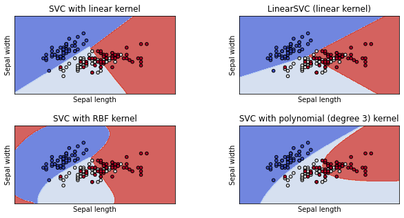

```python
visualize_svms(X, y, models, titles, subplot_shape=(2, 2))
```

### Plot performance measures

- In the following, we assess the performance of the classifier.
- We calculate the following metrics: Accuracy, Precision, Recall, and F1-score.
- We will explore those metrics in more detail in the next session.
- For now, it is sufficient to know how they are called and that they exist.

🤓: Which classifier do you think performs worst?  
🤓: SVM has low performance. Change the parameters, does performance increase?

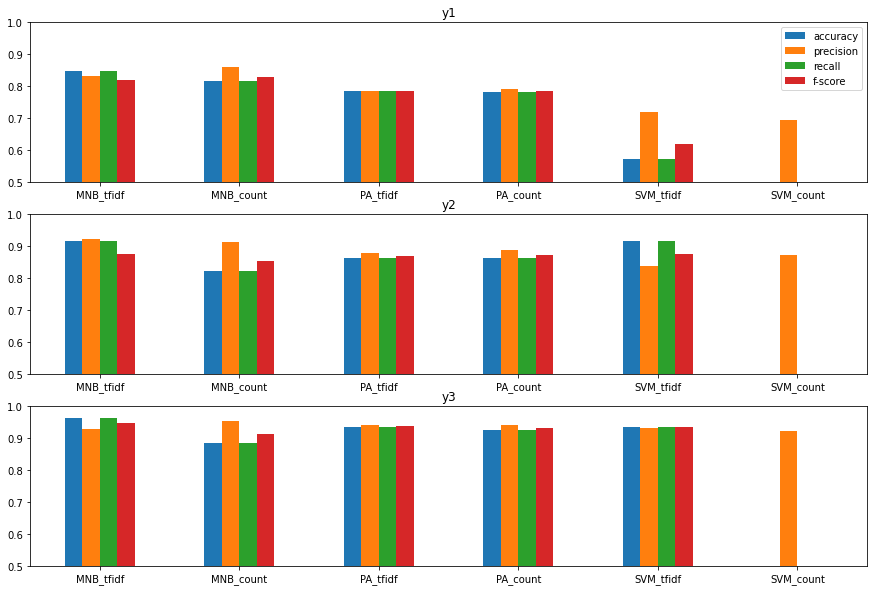

```python
plot_args = {"rot": 0, "figsize": (15, 10), "ylim": (0.5, 1)}
fig, axes = plt.subplots(nrows=3, ncols=1)
pd.DataFrame(results["y1"]).T.plot.bar(ax=axes[0], title="y1", **plot_args)
pd.DataFrame(results["y2"]).T.plot.bar(ax=axes[1], title="y2", legend=False, **plot_args)
pd.DataFrame(results["y3"]).T.plot.bar(ax=axes[2], title="y3", legend=False, **plot_args);
```

### Introspect features

- One can access the feature importance of many (mostly linear) classifiers in sk-learn. We saved the most predictive features (for class=1) when fitting the classifiers and can now access them.

We can look at the 20 most predictive features for our classifiers. (Please keep in mind that those are less meaningful for weak models)

```python
df = pd.DataFrame()
for y, features in most_predictive_features.items():
    _df = pd.DataFrame(features).applymap(lambda x: x[1])
    _df.columns = pd.MultiIndex.from_product([_df.columns, [y]])
    df = pd.concat([df, _df], axis=1)
df = df.sort_index(axis=1, level=0)
df
```

|  | MNB_count y1 | MNB_count y2 | MNB_count y3 | MNB_tfidf y1 | MNB_tfidf y2 | MNB_tfidf y3 | PA_count y1 | PA_count y2 | PA_count y3 | PA_tfidf y1 | PA_tfidf y2 | PA_tfidf y3 | SVM_count y1 | SVM_count y2 | SVM_count y3 | SVM_tfidf y1 | SVM_tfidf y2 | SVM_tfidf y3 |
| --- | --- | --- | --- | --- | --- | --- | --- | --- | --- | --- | --- | --- | --- | --- | --- | --- | --- | --- |
| 0 | risk | tax | tax | group | group | group | authorized | supplemented | restitution | introduc | uipment | anking | repor | repor | officer | realizable | sell | gilt |
| 1 | tax | risk | risk | financial | management | management | regarded | analysed | rubis | column | curren | reconcilliation | storage | mai | chief | introduc | vent | deferr |
| 2 | group | group | group | management | company | control | column | curred | xastatements | successively | nking | rom | sa | owing | financial | raise | carefully | oversight |
| 3 | financial | financial | management | business | financial | department | postemployment | elster | rom | onnel | claimed | appetite | parent | capacity | ensures | calculation | appropr | private |
| 4 | management | management | control | legal | business | committee | ected | importation | regularly | authorized | hourly | xlooking | activity | case | field | inside | iate | integrity |
| 5 | business | company | financial | control | law | policy | contra | compensa | mandatorily | raise | drop | xaevent | relating | identified | identification | proj | pbt | brazil |
| 6 | change | change | policy | company | authority | compliance | secure | carefully | opposite | econciliation | curred | ues | income | segment | applied | vent | mandatorily | rom |
| 7 | company | business | committee | change | change | internal | earning | parental | minimises | regarded | reverse | gilt | xchanges | increase | correctly | ppe | related | model |
| 8 | legal | provision | business | law | control | audit | adop | producer | reconcilliation | hort | vertible | opposite | criterion | hedging | reputation | speci | topic | garm |
| 9 | rate | income | audit | regulation | audit | authority | ge | hourly | redundancy | servicing | supplemented | dependent | year | determined | private | terminal | loan | position |
| 10 | control | rate | compliance | committee | policy | business | xasa | reverse | supplemented | iteration | strengthening | restitution | servizi | internal | performed | wbcsd | portfolio | vision |
| 11 | provision | liability | provision | compliance | committee | financial | iteration | fap | gilt | dget | parental | autho | azienda | institution | evaluation | care | att | oecd |
| 12 | asset | law | internal | rate | income | strategy | elster | strengthening | engages | replenishment | erage | mandatorily | basis | resulting | considers | iteration | xataxation | reviewgovernance |
| 13 | liability | control | department | regulatory | compliance | legal | leighton | claimed | realignment | prescribed | iti | supplemented | institution | new | specifically | reserve | discussed | benefi |
| 14 | income | authority | company | audit | provision | provision | prescribed | complexity | djusted | cumulated | xgeneral | firstgroup | management | intellectual | process | ected | covered | demonstrate |
| 15 | law | audit | rate | policy | liability | company | supplemented | guidance | particularly | supplemented | complianceen | xastatements | asset | disclosure | loan | world | activity | invoked |
| 16 | related | asset | change | country | legal | liability | ency | qxd | carefully | secure | elster | complexity | mainly | gbl | profile | necessitates | uipment | thing |
| 17 | audit | legal | authority | liability | regulation | board | investmen | collective | comparing | leighton | curreny | particularly | loss | goodwill | barclays | tion | ct | underlying |
| 18 | market | policy | liability | including | result | change | diversified | vent | pandemic | contra | importation | anomaly | deferral | consistent | tax | strategy | nking | significant |
| 19 | regulation | result | legal | related | department | governance | producer | iti | dependent | suggestion | analysed | increasingly | higher | barclays | using | baltic | committee | surveillance |

## Gazetteer versus Random Guess

### Gazetteer

- Gazetteers are named entity dictionaries.
- They can be interpreted as external knowledge sources.
- They include a vast amount of information, for example from Wikipedia (see for example [Higashinaka (2012)](https://aclanthology.org/C12-1071.pdf)
- We follow a very simple strategy:
  - We determine if a paragraph can be considered as containing references to tax risk management or not.
  - If $c$ keywords are present in the text then it can be considered as tax risk management.

```python
def gazetteer(text, count=1):
    """
    Args:
        text: `string` text to analyze
        count: `int` the number of keywords to match

    Returns:
        `Boolean`
    """
    gazetteer = ["tax", "risk", "risks", "group", "financial",
                 "management", "changes", "business", "legal",
                 "company", "authorities", "compliance",
                 "taxes", "regulations", "law", "related", "control", "laws", "committee"]

    # counter
    c = 0
    for g in gazetteer:
        if g in text:
            c += 1
    if c == count:
        return 1
    else:
        return 0
```

### Visualization

🤓: Compare the performance of the Gazetteer against one of the baseline models.

```python
def visualize(y_i, verbose=True, ax=None):
    x = ['Gazetteer: Train', 'Random Guess: Train', 'Gazetteer: Test', 'Random Guess: Test']
    y = [gazetteer_results[y_i]["train"]["gazetteer"]["accuracy"],
         gazetteer_results[y_i]["train"]["random_guess"]["accuracy"],
         gazetteer_results[y_i]["test"]["gazetteer"]["accuracy"],
         gazetteer_results[y_i]["test"]["random_guess"]["accuracy"]
         ]
    ax = sns.barplot(x, y, ax=ax)
    ax.set(xlabel='Methods', ylabel='Accuracy')
    ax.set_title(f'{y_i}')
    ax.set(ylim=(0, 1))
    ax.tick_params(labelrotation=25)
    return ax
```

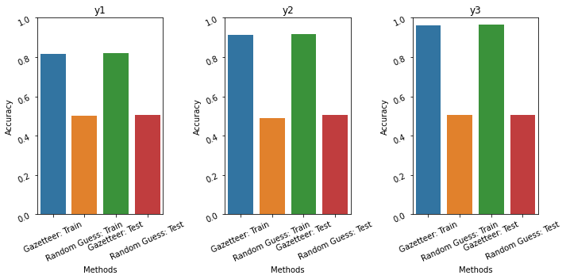

```python
fig, ax = plt.subplots(1, 3, figsize=(10, 5))
visualize('y1', ax=ax[0])
visualize('y2', ax=ax[1])
visualize('y3', ax=ax[2])
plt.tight_layout()
```

```python
pd.DataFrame(gazetteer_results["y1"]["test"])
```

|  | random_guess | gazetteer |
| --- | --- | --- |
| accuracy | 0.504792 | 0.819808 |
| precision | 0.702931 | 0.672324 |
| recall | 0.504792 | 0.819808 |
| f-score | 0.561642 | 0.738777 |

# It's your turn! 🧑‍💻 ~15'